# lab10

## Lab 10 - Fine-Tune VGG16 for Bird Classification

```python
# Importing necessary libraries
import os
import pathlib
import numpy as np
import tensorflow as tf
from tensorflow import keras
from tensorflow.keras.preprocessing.image import ImageDataGenerator
from tensorflow.keras.applications import VGG16
from tensorflow.keras import layers, models
from sklearn.metrics import classification_report, confusion_matrix, precision_recall_curve, auc
import matplotlib.pyplot as plt
```

### 1.Obtain the Data

```
      i.Download the BIRDS 525 SPECIES dataset from Kaggle (CC0 license). You will need to create a free Kaggle account, and this will provide you free access to many such datasets, as well as code and even online notebooks.
```

```python
# Setting directory paths for training, validation, and testing
base_dir = pathlib.Path("C:/Users/91902/Downloads/archive (1)")
train_dir = base_dir / 'train'
valid_dir = base_dir / 'valid'
test_dir = base_dir / 'test'
```

```python
dataset_directory = "C:/Users/91902/Downloads/archive (1)/train"


# Listing all items in the dataset directory
items_in_dataset = os.listdir(dataset_directory)

# Filtering out only directories (which correspond to class names)
class_names = [item for item in items_in_dataset if os.path.isdir(os.path.join(dataset_directory, item))]

# outputting the class names
print("Class names in the dataset directory:")
for class_name in class_names:
    print(class_name)
```

```
Class names in the dataset directory:
ABBOTTS BABBLER
ABBOTTS BOOBY
ABYSSINIAN GROUND HORNBILL
AFRICAN CROWNED CRANE
AFRICAN EMERALD CUCKOO
AFRICAN FIREFINCH
AFRICAN OYSTER CATCHER
AFRICAN PIED HORNBILL
AFRICAN PYGMY GOOSE
ALBATROSS
ALBERTS TOWHEE
ALEXANDRINE PARAKEET
ALPINE CHOUGH
ALTAMIRA YELLOWTHROAT
AMERICAN AVOCET
AMERICAN BITTERN
AMERICAN COOT
AMERICAN DIPPER
AMERICAN FLAMINGO
AMERICAN GOLDFINCH
AMERICAN KESTREL
AMERICAN PIPIT
AMERICAN REDSTART
AMERICAN ROBIN
AMERICAN WIGEON
AMETHYST WOODSTAR
ANDEAN GOOSE
ANDEAN LAPWING
ANDEAN SISKIN
ANHINGA
ANIANIAU
ANNAS HUMMINGBIRD
ANTBIRD
ANTILLEAN EUPHONIA
APAPANE
APOSTLEBIRD
ARARIPE MANAKIN
ASHY STORM PETREL
ASHY THRUSHBIRD
```

[output cut: 471 more lines]

```
WHITE NECKED RAVEN
WHITE TAILED TROPIC
WHITE THROATED BEE EATER
WILD TURKEY
WILLOW PTARMIGAN
WILSONS BIRD OF PARADISE
WOOD DUCK
WOOD THRUSH
WOODLAND KINGFISHER
WRENTIT
YELLOW BELLIED FLOWERPECKER
YELLOW BREASTED CHAT
YELLOW CACIQUE
YELLOW HEADED BLACKBIRD
ZEBRA DOVE
```

```
     iii.For this lab, we will work with the 3 classes with the highest number of images. Identify those classes, and use only these for the next steps. You can delete/discard the others.
```

```python
# Setting the path to the training dataset directory
train_directory_path = "C:/Users/91902/Downloads/archive (1)/train"

# Let's get all items in the directory that are directories themselves
class_directories = [d for d in os.listdir(train_directory_path) if os.path.isdir(os.path.join(train_directory_path, d))]

# Creating a dictionary to hold class names and their corresponding image counts
class_image_count = {}

# Looping through each class directory and count the number of files
for class_dir in class_directories:
    class_dir_path = os.path.join(train_directory_path, class_dir)
    class_image_count[class_dir] = len(os.listdir(class_dir_path))

# Sorting classes by image count in descending order
sorted_classes = sorted(class_image_count.items(), key=lambda item: item[1], reverse=True)

# Taking the top three classes
top_three_classes = sorted_classes[:3]

# outputting the top three classes
for class_name, count in top_three_classes:
    print(f"Class: {class_name}, Image Count: {count}")
```

```
Class: RUFOUS TREPE, Image Count: 263
Class: HOUSE FINCH, Image Count: 248
Class: D-ARNAUDS BARBET, Image Count: 233
```

## 2.Use data-augmentation to increase the number of training images. You are encouraged to try out various augmentation methods supported by Keras. The rule of thumb is that as long as an augmentation produces realistic images - it is probably a good idea to add it.(2 point)

```python
# Defining ImageDataGenerator with augmentation for the training data
train_datagen = ImageDataGenerator(
    rescale=1.0/255,
    rotation_range=40,
    width_shift_range=0.2,
    height_shift_range=0.2,
    shear_range=0.2,
    zoom_range=0.2,
    horizontal_flip=True,
    fill_mode='nearest'
)

# Defining the top three classes
top_classes = ['RUFOUS TREPE', 'HOUSE FINCH', 'D-ARNAUDS BARBET']

# Now let's flow the data from the directory and filter only the top three classes for training
train_generator = train_datagen.flow_from_directory(
    'C:/Users/91902/Downloads/archive (1)/train',
    target_size=(224, 224),
    batch_size=32,
    class_mode='categorical',
    classes=top_classes
)

# Setting up the validation data generator without augmentation, but only for top classes
valid_datagen = ImageDataGenerator(rescale=1.0/255)
valid_generator = valid_datagen.flow_from_directory(
    'C:/Users/91902/Downloads/archive (1)/valid',
    target_size=(224, 224),
    batch_size=32,
    class_mode='categorical',
    classes=top_classes
)

# Setting up the test data generator
test_datagen = ImageDataGenerator(rescale=1.0/255)
test_generator = test_datagen.flow_from_directory(
    'C:/Users/91902/Downloads/archive (1)/test',
    target_size=(224, 224),
    batch_size=32,
    class_mode='categorical',
    classes=top_classes
)
```

```
Found 744 images belonging to 3 classes.
Found 15 images belonging to 3 classes.
Found 15 images belonging to 3 classes.
```

```python
base_model  = keras.applications.vgg16.VGG16(
    weights="imagenet",
    include_top=False,
    input_shape=(224,224,3))
base_model.summary()
```

```
Model: "vgg16"
_________________________________________________________________
 Layer (type)                Output Shape              Param #
=================================================================
 input_2 (InputLayer)        [(None, 224, 224, 3)]     0

 block1_conv1 (Conv2D)       (None, 224, 224, 64)      1792

 block1_conv2 (Conv2D)       (None, 224, 224, 64)      36928

 block1_pool (MaxPooling2D)  (None, 112, 112, 64)      0

 block2_conv1 (Conv2D)       (None, 112, 112, 128)     73856

 block2_conv2 (Conv2D)       (None, 112, 112, 128)     147584

 block2_pool (MaxPooling2D)  (None, 56, 56, 128)       0

 block3_conv1 (Conv2D)       (None, 56, 56, 256)       295168

 block3_conv2 (Conv2D)       (None, 56, 56, 256)       590080

 block3_conv3 (Conv2D)       (None, 56, 56, 256)       590080

 block3_pool (MaxPooling2D)  (None, 28, 28, 256)       0

 block4_conv1 (Conv2D)       (None, 28, 28, 512)       1180160

 block4_conv2 (Conv2D)       (None, 28, 28, 512)       2359808

 block4_conv3 (Conv2D)       (None, 28, 28, 512)       2359808

 block4_pool (MaxPooling2D)  (None, 14, 14, 512)       0

 block5_conv1 (Conv2D)       (None, 14, 14, 512)       2359808

 block5_conv2 (Conv2D)       (None, 14, 14, 512)       2359808

 block5_conv3 (Conv2D)       (None, 14, 14, 512)       2359808

 block5_pool (MaxPooling2D)  (None, 7, 7, 512)         0

=================================================================
Total params: 14,714,688
Trainable params: 14,714,688
Non-trainable params: 0
_________________________________________________________________
```

```python
# Adding custom layers on top of the pre-loaded VGG16 model
model = models.Sequential()
model.add(base_model)  # base_model is your pre-loaded VGG16 model
model.add(layers.Flatten())
model.add(layers.Dense(256, activation='relu'))
model.add(layers.Dropout(0.5))
model.add(layers.Dense(3, activation='softmax'))  # 3 units for 3 classes

# Freezing the layers of the base model
base_model.trainable = False

# Let's compile the model
model.compile(optimizer='adam', loss='categorical_crossentropy', metrics=['accuracy'])

# Training the model
history = model.fit(train_generator, epochs=10, validation_data=valid_generator)

# Evaluation on test data
test_loss, test_acc = model.evaluate(test_generator)
print(f"Test accuracy: {test_acc:.3f}")
```

```
Test accuracy: 1.000
```

## 3.Fine-Tune VGG16 (pre-trained on imagenet), to classify the 3 classes (2 points)

```python
# Again Loading the VGG16 model, pre-trained on ImageNet data, but without the top layer
base_model = VGG16(weights='imagenet', include_top=False, input_shape=(224, 224, 3))

# Freezing the layers of the base model
for layer in base_model.layers:
    layer.trainable = False

# Adding custom layers on top for our specific task
model = models.Sequential()
model.add(base_model)
model.add(layers.Flatten())

# Adding a fully connected layer
model.add(layers.Dense(256, activation='relu'))

# Adding a dropout layer for regularization (helps reduce overfitting)
model.add(layers.Dropout(0.5))

# The final layer with softmax activation for classification
model.add(layers.Dense(3, activation='softmax'))  # 3 units for 3 classes
```

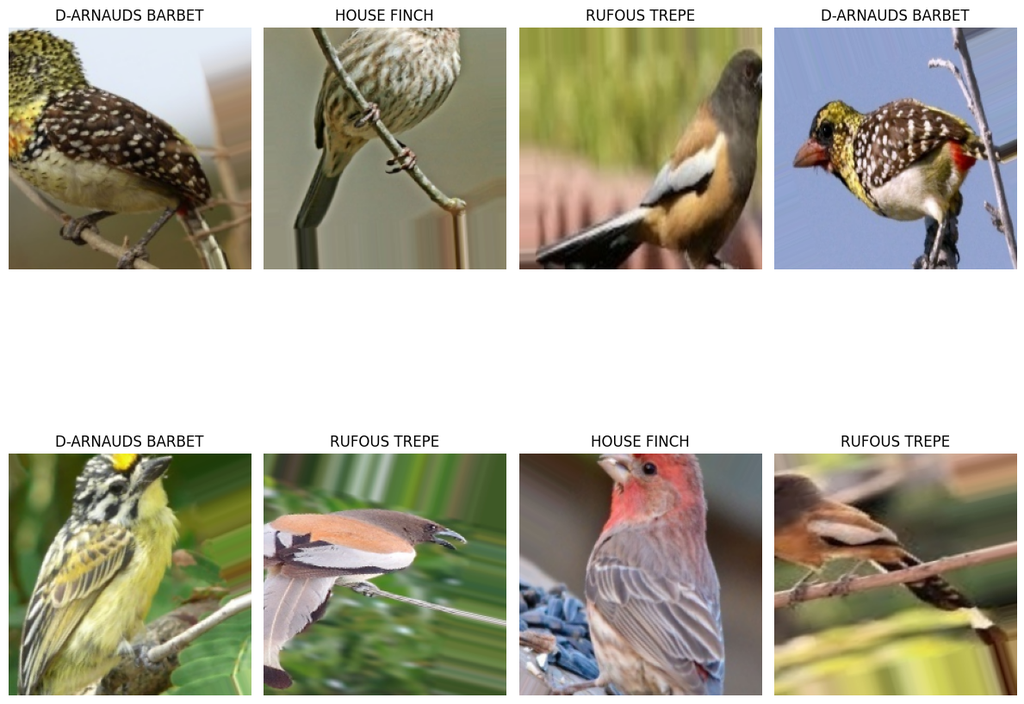

```python
import matplotlib.pyplot as plt

# Getting a batch of images and labels
images, labels = next(train_generator)

# Setting the number of images you want to display
num_images = 8  # Feel free to change this number

# Converting the dict_keys object to a list for indexing
class_labels = list(train_generator.class_indices.keys())

plt.figure(figsize=(12, 12))
for i in range(num_images):
    # Plotting the images
    plt.subplot(num_images // 4, 4, i + 1)


    # Rescaling images to 0-255 range since they were rescaled to 0-1 range during augmentation
    img = images[i] * 255

    plt.imshow(img.astype('uint8'))
    plt.axis('off')

    # Adding titles with the class labels
    # And the labels are one-hot encoded
    label_index = np.argmax(labels[i])
    plt.title(class_labels[label_index])

plt.tight_layout()
plt.show()
```

```python
# Compiling the model
model.compile(
    optimizer='adam',  # Optimizer
    loss='categorical_crossentropy',  # Loss function for multi-class classification
    metrics=['accuracy']  # Metric to monitor for performance
)
```

```python
# Evaluating the model on the test data
test_loss, test_accuracy = model.evaluate(test_generator)

# Outputing the results
print(f"Test Loss: {test_loss:.4f}")
print(f"Test Accuracy: {test_accuracy:.4f}")
```

```
Test Loss: 1.1771
Test Accuracy: 0.2667
```

```python
# Getting predictions
predictions = model.predict(test_generator)

# Converting predictions to discrete values (class indices)
predicted_classes = np.argmax(predictions, axis=1)

# Getting the true classes
true_classes = test_generator.classes

# Getting the class labels
class_labels = list(test_generator.class_indices.keys())

# Printing the classification report
test_loss, test_accuracy = model.evaluate(test_generator)

# Outputing the results
print(f"Test Loss: {test_loss:.4f}")
print(f"Test Accuracy: {test_accuracy:.4f}")

# Printing confusion matrix
from sklearn.metrics import confusion_matrix, classification_report
conf_matrix = confusion_matrix(true_classes, predicted_classes)
print(conf_matrix)

# Printing classification report
print(classification_report(true_classes, predicted_classes, target_names=class_labels))
```

```
Test Loss: 1.1771
Test Accuracy: 0.2667
[[3 2 0]
 [2 2 1]
 [1 2 2]]
                  precision    recall  f1-score   support

    RUFOUS TREPE       0.50      0.60      0.55         5
     HOUSE FINCH       0.33      0.40      0.36         5
D-ARNAUDS BARBET       0.67      0.40      0.50         5

        accuracy                           0.47        15
       macro avg       0.50      0.47      0.47        15
    weighted avg       0.50      0.47      0.47        15
```

And the confusion matrix and classification report provide additional insight into the model's performance across the three bird classes. For "RUFOUS TREPE," the model has a precision of 50% and a recall of 60%, meaning it can identify this class relatively better than the others. "HOUSE FINCH" has a lower precision and recall, indicating more confusion when predicting this class. "D-ARNAUDS BARBET" shows a higher precision but lower recall, suggesting the model is more conservative but accurate when it predicts this class.

In simpler terms, the model is somewhat capable of recognizing "D-ARNAUDS BARBET" when it sees it, but it misses several instances. It can recognize "RUFOUS TREPE" more frequently, but it also mistakes other birds for this class. For "HOUSE FINCH," both the recognition frequency and the accuracy are moderate.

Overall, there's a balanced performance across classes (as indicated by the macro average scores), but I believe there is room for improvement. To enhance the model's accuracy, consider gathering more data, especially for the validation and testing sets, as the small size of these sets can impact the evaluation metrics. Additionally, further hyperparameter tuning, experimenting with different architectures, or applying more advanced data augmentation techniques could also help improve the model's performance.